# Coursera Practical Machine Learning Project

Aynalem Mekbib

Apr 20, 2019

## Synopsis

The goal of this project is to quantify how well people do their exercises regularly by analyzing data collected from accelerometers on exercise machine belts, forearm arm and dumbbell of 6 participants. The project will classify the performed exercise into five categories:  
Class A : exactly according to the specification  
Class B: throwing the elbows to the front  
Class C: lifting the dumbbell only halfway  
Class D: lowering the dumbbell only halfway  
Class E: throwing the hips to the front

Using devices such as Jawbone Up, Nike FuelBand, and Fitbit it is now possible to collect a large amount of data about personal activity relatively inexpensively. These type of devices are part of the quantified self movement – a group of enthusiasts who take measurements about themselves regularly to improve their health, to find patterns in their behavior, or because they are tech geeks. One thing that people regularly do is quantify how much of a particular activity they do, but they rarely quantify how well they do it. This project will usee data from accelerometers on the belt, forearm, arm, and dumbbell of participants to analyze if barbell lifts were done in 5 different ways. Data source for this project comes from http://web.archive.org/web/20161224072740/http:/groupware.les.inf.puc-rio.br/har (see the section on the Weight Lifting Exercise Dataset).

```r
library(knitr)
library(pdftools)
library(caret)
```

## Data

Download training and test data.

```r
download.file("https://d396qusza40orc.cloudfront.net/predmachlearn/pml-training.csv","pml-training.csv")
download.file("https://d396qusza40orc.cloudfront.net/predmachlearn/pml-testing.csv","pml-testing.csv")
```

Extract data

```r
train <- read.csv("G:/R/machinelearning/pml-training.csv", header = TRUE)
test <- read.csv("G:/R/machinelearning/pml-testing.csv", header = TRUE)
```

Training data consists of 19622 rows and 160 columns.  
Testing data consists of 20 rows and 160 columns.

Verify column name match in the training and test set.

```r
setdiff(colnames(train),colnames(test))
```

```
## [1] "classe"
```

```r
setdiff(colnames(test),colnames(train))
```

```
## [1] "problem_id"
```

```r
intersect(colnames(train),colnames(test))
```

```
##   [1] "X"                        "user_name"                "raw_timestamp_part_1"     "raw_timestamp_part_2"
##   [5] "cvtd_timestamp"           "new_window"               "num_window"               "roll_belt"
##   [9] "pitch_belt"               "yaw_belt"                 "total_accel_belt"         "kurtosis_roll_belt"
##  [13] "kurtosis_picth_belt"      "kurtosis_yaw_belt"        "skewness_roll_belt"       "skewness_roll_belt.1"
##  [17] "skewness_yaw_belt"        "max_roll_belt"            "max_picth_belt"           "max_yaw_belt"
##  [21] "min_roll_belt"            "min_pitch_belt"           "min_yaw_belt"             "amplitude_roll_belt"
##  [25] "amplitude_pitch_belt"     "amplitude_yaw_belt"       "var_total_accel_belt"     "avg_roll_belt"
##  [29] "stddev_roll_belt"         "var_roll_belt"            "avg_pitch_belt"           "stddev_pitch_belt"
##  [33] "var_pitch_belt"           "avg_yaw_belt"             "stddev_yaw_belt"          "var_yaw_belt"
##  [37] "gyros_belt_x"             "gyros_belt_y"             "gyros_belt_z"             "accel_belt_x"
##  [41] "accel_belt_y"             "accel_belt_z"             "magnet_belt_x"            "magnet_belt_y"
##  [45] "magnet_belt_z"            "roll_arm"                 "pitch_arm"                "yaw_arm"
##  [49] "total_accel_arm"          "var_accel_arm"            "avg_roll_arm"             "stddev_roll_arm"
##  [53] "var_roll_arm"             "avg_pitch_arm"            "stddev_pitch_arm"         "var_pitch_arm"
##  [57] "avg_yaw_arm"              "stddev_yaw_arm"           "var_yaw_arm"              "gyros_arm_x"
```

[output cut: 25 more lines]

Training and test data contain same predictors.

## Data Cleansing

#### Remove non-predictor variables

Remove the first 7 columns of trainer data that will not be part of predictors. They contain user information and time stamps.

```r
head(train[,c(1:7)],6)
```

```
##   X user_name raw_timestamp_part_1 raw_timestamp_part_2   cvtd_timestamp new_window num_window
## 1 1  carlitos           1323084231               788290 05/12/2011 11:23         no         11
## 2 2  carlitos           1323084231               808298 05/12/2011 11:23         no         11
## 3 3  carlitos           1323084231               820366 05/12/2011 11:23         no         11
## 4 4  carlitos           1323084232               120339 05/12/2011 11:23         no         12
## 5 5  carlitos           1323084232               196328 05/12/2011 11:23         no         12
## 6 6  carlitos           1323084232               304277 05/12/2011 11:23         no         12
```

```r
trainclean <- train[,-c(1:7)]
```

train data contains 19622 observations and 153 variables.

Remove the first 7 columns from test data.

```r
testclean <- test[,-c(1:7)]
```

test data contains 20 observations and 153 variables.

#### Remove NA columns

Remove columns that are over 90% with NAs or empty values.

```r
nacol <- which(colSums(is.na(trainclean) | trainclean == "" )  > 0.9*dim(trainclean)[1])
traindata <- trainclean[,-nacol]
```

Cleansed training data contains 19622 observations and 53 variables.

Remove missing columns from test data

```r
nacol <- which(colSums(is.na(testclean) | testclean == "" )  > 0.9*dim(testclean)[1])
testdata <- testclean[,-nacol]
```

Cleansed test data contains 20 observations and 53 variables.

#### Target Column

Outcome variable is column classe and other columns are predictors. The models below will measure the exercises against the classe variable.

```r
unique(train$classe)
```

```
## [1] A B C D E
## Levels: A B C D E
```

Classe variable contains 5 methods of doing the exercises.

### Data Partition

Partition training data set into two,70% training and 30% testing sets.

```r
set.seed(12345)
partcols <- createDataPartition(y=traindata$classe, p=0.7, list=FALSE)
newtrain <- traindata[partcols,]
newtest <- traindata[-partcols,]
```

Model uses 5-fold cross validation

```r
trcontrol <- trainControl(method="cv", number=5)
modelCV <- train(classe~., data=newtrain, method="rpart", trControl=trcontrol)
modelCV
```

```
## CART
##
## 13737 samples
##    52 predictor
##     5 classes: 'A', 'B', 'C', 'D', 'E'
##
## No pre-processing
## Resampling: Cross-Validated (5 fold)
## Summary of sample sizes: 10990, 10989, 10990, 10989, 10990
## Resampling results across tuning parameters:
##
##   cp          Accuracy   Kappa
##   0.03753433  0.5245657  0.38369289
##   0.05987862  0.4396900  0.24892937
##   0.11585800  0.3165163  0.04927296
##
## Accuracy was used to select the optimal model using the largest value.
## The final value used for the model was cp = 0.03753433.
```

#### Prediction(CV)

Validate model with test data and create confusion matrix

```r
modelCVpredict <- predict(modelCV,newdata=newtest)
modelCVconfusion <- confusionMatrix(modelCVpredict,newtest$classe)
modelCVconfusion
```

```
## Confusion Matrix and Statistics
##
##           Reference
## Prediction    A    B    C    D    E
##          A 1494  470  467  438  141
##          B   21  380   29  184  147
##          C  128  289  530  342  277
##          D    0    0    0    0    0
##          E   31    0    0    0  517
##
## Overall Statistics
##
##                Accuracy : 0.4963
##                  95% CI : (0.4835, 0.5092)
##     No Information Rate : 0.2845
##     P-Value [Acc > NIR] : < 2.2e-16
##
##                   Kappa : 0.3425
##
##  Mcnemar's Test P-Value : NA
##
## Statistics by Class:
##
##                      Class: A Class: B Class: C Class: D Class: E
## Sensitivity            0.8925  0.33363  0.51657   0.0000  0.47782
## Specificity            0.6400  0.91972  0.78679   1.0000  0.99355
## Pos Pred Value         0.4963  0.49934  0.33844      NaN  0.94343
## Neg Pred Value         0.9374  0.85187  0.88516   0.8362  0.89414
## Prevalence             0.2845  0.19354  0.17434   0.1638  0.18386
## Detection Rate         0.2539  0.06457  0.09006   0.0000  0.08785
## Detection Prevalence   0.5115  0.12931  0.26610   0.0000  0.09312
## Balanced Accuracy      0.7662  0.62667  0.65168   0.5000  0.73568
```

Model shows an accuracy of 0.4963466.

### Gradient Boosting Model(GBM)

```r
trControl <- trainControl(method = "repeatedcv", number = 5, repeats = 5)
modelGBM <- train(classe ~ ., data = newtrain, method = "gbm", trControl = trControl, verbose=FALSE)
modelGBM
```

```
## Stochastic Gradient Boosting
##
## 13737 samples
##    52 predictor
##     5 classes: 'A', 'B', 'C', 'D', 'E'
##
## No pre-processing
## Resampling: Cross-Validated (5 fold, repeated 5 times)
## Summary of sample sizes: 10989, 10990, 10990, 10989, 10990, 10990, ...
## Resampling results across tuning parameters:
##
##   interaction.depth  n.trees  Accuracy   Kappa
##   1                   50      0.7539627  0.6880080
##   1                  100      0.8244005  0.7777379
##   1                  150      0.8563584  0.8182221
##   2                   50      0.8574501  0.8193601
##   2                  100      0.9078254  0.8833413
##   2                  150      0.9328091  0.9149718
##   3                   50      0.8977938  0.8706189
##   3                  100      0.9425783  0.9273408
##   3                  150      0.9624515  0.9524917
##
## Tuning parameter 'shrinkage' was held constant at a value of 0.1
## Tuning parameter 'n.minobsinnode' was held constant
##  at a value of 10
## Accuracy was used to select the optimal model using the largest value.
## The final values used for the model were n.trees = 150, interaction.depth = 3, shrinkage = 0.1 and n.minobsinnode = 10.
```

#### Prediction(GBM)

Validate model with test data and create confusion matrix

```r
modelGBMpredict <- predict(modelGBM, newdata=newtest)
modelGBMconfusion <- confusionMatrix(modelGBMpredict, newtest$classe)
modelGBMconfusion
```

```
## Confusion Matrix and Statistics
##
##           Reference
## Prediction    A    B    C    D    E
##          A 1644   44    0    3    2
##          B   21 1062   35    5   16
##          C    4   30  970   34    6
##          D    5    3   19  916   19
##          E    0    0    2    6 1039
##
## Overall Statistics
##
##                Accuracy : 0.9568
##                  95% CI : (0.9513, 0.9619)
##     No Information Rate : 0.2845
##     P-Value [Acc > NIR] : < 2.2e-16
##
##                   Kappa : 0.9454
##
##  Mcnemar's Test P-Value : 2.645e-06
##
## Statistics by Class:
##
##                      Class: A Class: B Class: C Class: D Class: E
## Sensitivity            0.9821   0.9324   0.9454   0.9502   0.9603
## Specificity            0.9884   0.9838   0.9848   0.9907   0.9983
## Pos Pred Value         0.9711   0.9324   0.9291   0.9522   0.9924
## Neg Pred Value         0.9928   0.9838   0.9884   0.9902   0.9911
## Prevalence             0.2845   0.1935   0.1743   0.1638   0.1839
## Detection Rate         0.2794   0.1805   0.1648   0.1556   0.1766
## Detection Prevalence   0.2877   0.1935   0.1774   0.1635   0.1779
## Balanced Accuracy      0.9852   0.9581   0.9651   0.9704   0.9793
```

Model shows an accuracy of 0.9568394.

### Random Forest (RF)

Using a 5 fold cross-validation with repeats = 5

```r
trControl = trainControl(method = "repeatedcv", number = 5,repeats = 5)
modelRF <- train(classe~., data=newtrain, method="rf", proxy=TRUE, trControl = trControl)
modelRF$finalModel
```

```
##
## Call:
##  randomForest(x = x, y = y, mtry = param$mtry, proxy = TRUE)
##                Type of random forest: classification
##                      Number of trees: 500
## No. of variables tried at each split: 2
##
##         OOB estimate of  error rate: 0.64%
## Confusion matrix:
##      A    B    C    D    E class.error
## A 3902    1    2    0    1 0.001024066
## B   18 2635    5    0    0 0.008653123
## C    0   22 2371    3    0 0.010434057
## D    0    0   28 2222    2 0.013321492
## E    0    0    0    6 2519 0.002376238
```

#### Prediction(RF)

```r
modelRFpredict <- predict(modelRF, newdata=newtest)
modelRFconfusion <- confusionMatrix(modelRFpredict , newtest$classe)
modelRFconfusion
```

```
## Confusion Matrix and Statistics
##
##           Reference
## Prediction    A    B    C    D    E
##          A 1673   11    0    0    0
##          B    1 1122   16    0    0
##          C    0    6 1007   24    0
##          D    0    0    3  940    4
##          E    0    0    0    0 1078
##
## Overall Statistics
##
##                Accuracy : 0.989
##                  95% CI : (0.9859, 0.9915)
##     No Information Rate : 0.2845
##     P-Value [Acc > NIR] : < 2.2e-16
##
##                   Kappa : 0.986
##
##  Mcnemar's Test P-Value : NA
##
## Statistics by Class:
##
##                      Class: A Class: B Class: C Class: D Class: E
## Sensitivity            0.9994   0.9851   0.9815   0.9751   0.9963
## Specificity            0.9974   0.9964   0.9938   0.9986   1.0000
## Pos Pred Value         0.9935   0.9851   0.9711   0.9926   1.0000
## Neg Pred Value         0.9998   0.9964   0.9961   0.9951   0.9992
## Prevalence             0.2845   0.1935   0.1743   0.1638   0.1839
## Detection Rate         0.2843   0.1907   0.1711   0.1597   0.1832
## Detection Prevalence   0.2862   0.1935   0.1762   0.1609   0.1832
## Balanced Accuracy      0.9984   0.9907   0.9877   0.9868   0.9982
```

#### Best fit

The three models are compared.

```r
modelAcc <- data.frame( Modeltype = c('CV', 'GBM','RF'),
                  Accuracy = rbind(round(modelCVconfusion$overall['Accuracy'], 4),
                                   round(modelGBMconfusion$overall['Accuracy'], 4),
                                  round(modelRFconfusion$overall['Accuracy'], 4)))
modelAcc
```

```
##   Modeltype Accuracy
## 1        CV   0.4963
## 2       GBM   0.9568
## 3        RF   0.9890
```

Random forest yields better result with an accuracy of 0.989.

##### RF - Accuracy

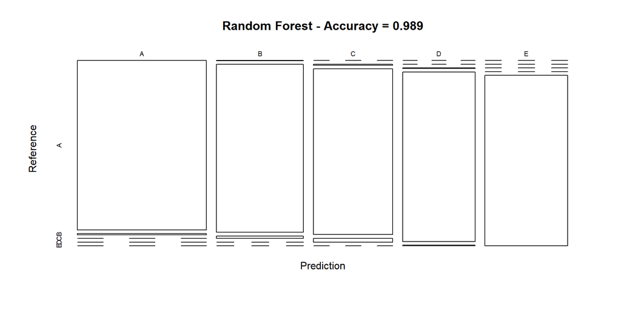

```r
plot(modelRFconfusion$table, col = modelRFconfusion$byClass,
     main = paste("Random Forest - Accuracy =",
                  round(modelRFconfusion$overall['Accuracy'], 4)))
```

```r
dev.copy2pdf(file = "RFAcc.pdf")
```

##### RF - Error

Measure OOB error rates of the model

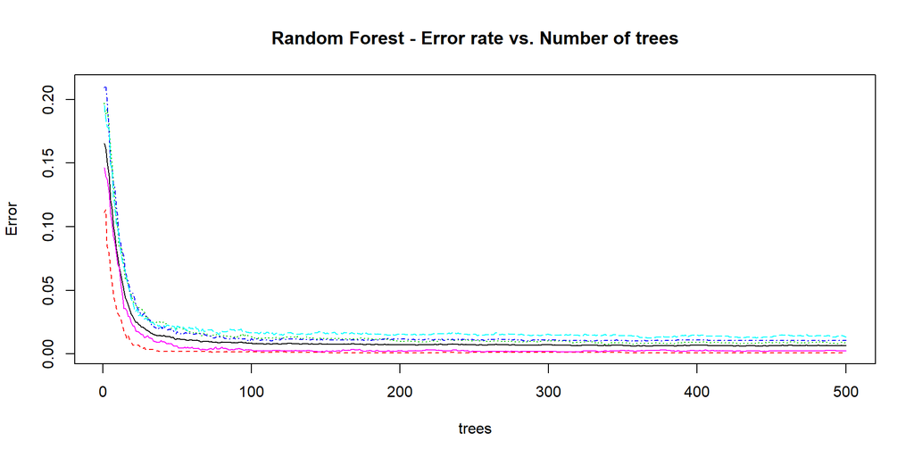

```r
plot(modelRF$finalModel, main="Random Forest - Error rate vs. Number of trees")
```

```r
dev.copy2pdf(file = "RFErr.pdf")
```

it shows that errors stabilize around 100 trees

Find which set of predictors give the best accuracy .

[figure not shown]

```r
ggplot(data=modelRF,aes(x=modelRF$results$mtry, y=modelRF$results$Accuracy)) +
             theme_classic() +
             labs(title="Random Forest - Accuracy vs. predictors",
                 x="RandomSelectedPredictors",
                 y="Accuracy(Bootstrap)")
```

```r
ggsave("RFPred.pdf")
```

#### RF - Variable importance

It may be of interest to know variables important in the random forest model.

[figure not shown]

```r
RFImp  <- varImp(modelRF)
ggplot(data=RFImp,aes(x=RFImp$importance$Overall, y=RFImp$importance)) +
          labs(title="Random Forest - Relative importance of predictor variable",
                 x="Importance",
                 y="Feature") +
          geom_bar(stat="identity",fill="navyblue",alpha=.8,width=.8)
```

```r
ggsave("RFImp.pdf")
dev.off()
```

Roll_belt has a significant impact in measuring the outcome of random forest model.

## Conclusion

Use the random forest model to predict the 20 quiz results.

```r
modelRFFinal <- predict(modelRF, newdata=test)
modelRFFinal
```

```
##  [1] B A B A A E D B A A B C B A E E A B B B
## Levels: A B C D E
```